# Case Study 3

Rachael Smith

May 12, 2020

```r
# Use this R-Chunk to import all your datasets!
flight_data_T3 <- nycflights13::flights
```

## Background

#### Give Your Visualization Wings to Fly

You just started your internship at a big firm in New York, and your manager gave you an extensive file of flights that departed JFK, LGA, or EWR in 2013. Your manager wants you to answer the following questions using data from in nycflights::flights:

## Analysis

#### Question 1:

Ultimately I found the simple table chart to be the most stratightforward way to quickly see which flights have the lowest delay time in the 75th percentile. “Q3” represents Quartile 3 from a boxplot which is the same as the 75th percentile.

I did not have the time to put the data in order, but I felt like there are few enough rows that it should be fairly easy to see. Sometimes, the fastest solution is the easiest.

```r
# Trying to determine which 2 airlines have the shortest arrival delays of flights that leave before noon at each airports.
fltdy1 <- nycflights13::flights %>%
  select(origin, carrier, dep_delay, arr_delay, dep_time) %>%
  filter(dep_time <= 1200 & carrier != "FL" & carrier != "F9") %>%
  group_by(origin, carrier) %>%
  summarise(Q3 = quantile(arr_delay, 0.75, na.rm = T), max = max(arr_delay, na.rm = T)) %>%
  select(Q3, origin, carrier, max)
```

##### 75th Percentile (Q3) Arrival Delays at JFK

###### Recommendation: DL & VX

I would recommend your using DL as your first choice from JFK. At the 75th percentile, DL planes that depart from JFK arrive at their destination 1 minute early.

I would recommend your using VX as your second choice from JFK. At the 75th percentile, VX planes that depart from JFK arrive at their destination 1 minute late.

```r
JFK_delay <- fltdy1 %>%
  filter(origin == "JFK")
pander(JFK_delay)
```

| Q3 | origin | carrier | max |
| --- | --- | --- | --- |
| 3 | JFK | 9E | 744 |
| 2 | JFK | AA | 1007 |
| 9 | JFK | B6 | 445 |
| -1 | JFK | DL | 931 |
| 6 | JFK | EV | 493 |
| 2 | JFK | HA | 1272 |
| 6 | JFK | MQ | 989 |
| 4 | JFK | UA | 373 |
| 7 | JFK | US | 232 |
| 1 | JFK | VX | 408 |

##### 75th Percentile (Q3) Arrival Delays at EWR

```r
EWR_delay <- fltdy1 %>%
  filter(origin == "EWR")
pander(EWR_delay)
```

| Q3 | origin | carrier | max |
| --- | --- | --- | --- |
| 2 | EWR | 9E | 311 |
| -1 | EWR | AA | 878 |
| -9 | EWR | AS | 198 |
| 0 | EWR | B6 | 366 |
| 3 | EWR | DL | 847 |
| 8 | EWR | EV | 463 |
| 10 | EWR | MQ | 1109 |
| 3 | EWR | UA | 352 |
| 4 | EWR | US | 229 |
| -3 | EWR | VX | 287 |
| 2 | EWR | WN | 399 |

##### 75th Percentile (Q3) Arrival Delays at LGA

###### Recommendation: YV & AA

I would recommend your using YV as your first choice from LGA. At the 75th percentile, YV planes that depart from LGA arrive at their destination 4 minutes early.

```r
LGA_delay <- fltdy1 %>%
  filter(origin == "LGA")
pander(LGA_delay)
```

| Q3 | origin | carrier | max |
| --- | --- | --- | --- |
| 2 | LGA | 9E | 246 |
| 1 | LGA | AA | 802 |
| 5 | LGA | B6 | 364 |
| 2 | LGA | DL | 821 |
| 3 | LGA | EV | 291 |
| 8 | LGA | MQ | 305 |
| 2 | LGA | UA | 378 |
| 2 | LGA | US | 485 |
| 3 | LGA | WN | 334 |
| -4 | LGA | YV | 42 |

This chart shows the complexity of the data involved in this assumption. Typically, a boxplot is the best way to determine the 75th percentile. All data below the top line of the white box represents the 75th percentile. With this much data it is difficult to tell which airline has the lowest delay at 75%.

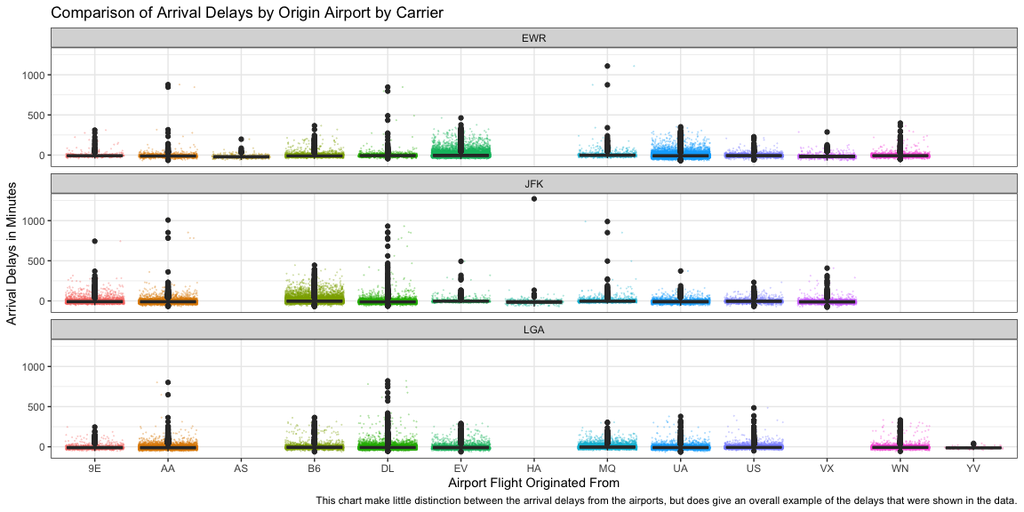

```r
# Use this R-Chunk to plot & visualize your data!
fltdy1a <- nycflights13::flights %>%
  select(origin, carrier, dep_delay, arr_delay, dep_time) %>%
  filter(dep_time <= 1200 & carrier != "FL" & carrier != "F9") %>%
  group_by(origin, carrier) %>%
  select(arr_delay, carrier, origin, dep_time, dep_delay)

ggplot(data = fltdy1a, aes(x = carrier, y = arr_delay)) +
  geom_jitter(inherit.aes = TRUE, height = 0, size = 0.025, alpha = 0.25, aes(color = carrier)) +
  geom_boxplot() +
  facet_wrap(~origin, ncol = 1) +
  labs(title = "Comparison of Arrival Delays by Origin Airport by Carrier", caption = "This chart make little distinction between the arrival delays from the airports, but does give an overall example of the delays that were shown in the data.",
       x = "Airport Flight Originated From", y = "Arrival Delays in Minutes") +
  theme_bw() +
  theme(legend.position = "none")
```

We can try getting closer to the data by looking at flights with arrival delays of 30 minutes or less, but there is still too much data to look at. In side the box represents 50 percent of the arrival times of the total number of flights per carrier.

*Each dot represents a single flight, which is helpful to understand the number of flights we are using for our comparison values.*

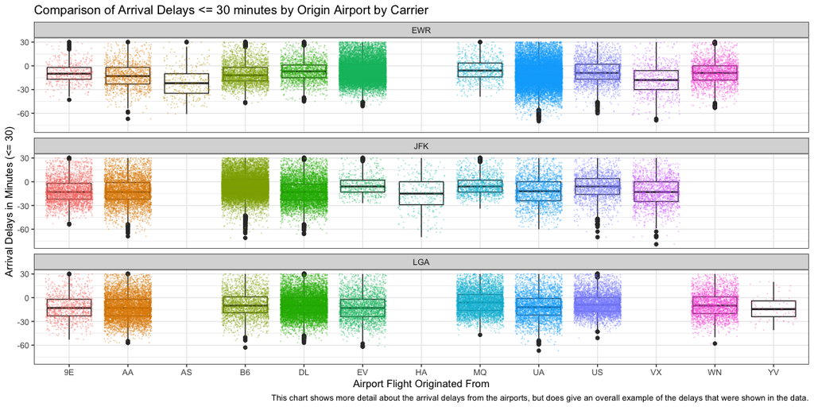

```r
# Use this R-Chunk to plot & visualize your data!
fltdy1c <- nycflights13::flights %>%
  select(origin, carrier, dep_delay, arr_delay, dep_time) %>%
  filter(dep_time <= 1200 & carrier != "FL" & carrier != "F9" & arr_delay <= 30) %>%
  group_by(origin, carrier) %>%
  select(arr_delay, carrier, origin, dep_time, dep_delay)

ggplot(data = fltdy1c, aes(x = carrier, y = arr_delay)) +
  geom_boxplot() +
  geom_jitter(inherit.aes = TRUE, height = 0, size = 0.025, alpha = 0.25, aes(color = carrier)) +
  facet_wrap(~origin, ncol = 1) +
  labs(title = "Comparison of Arrival Delays <= 30 minutes by Origin Airport by Carrier", caption = "This chart shows more detail about the arrival delays from the airports, but does give an overall example of the delays that were shown in the data.",
       x = "Airport Flight Originated From", y = "Arrival Delays in Minutes (<= 30)") +
  theme_bw() +
  theme(legend.position = "none")
```

## Conclusion:

In this chart we will remove all the data, except the top line of the boxplot which represents the 75th percentile. From this chart, you can quickly see which two airlines are the lowest.

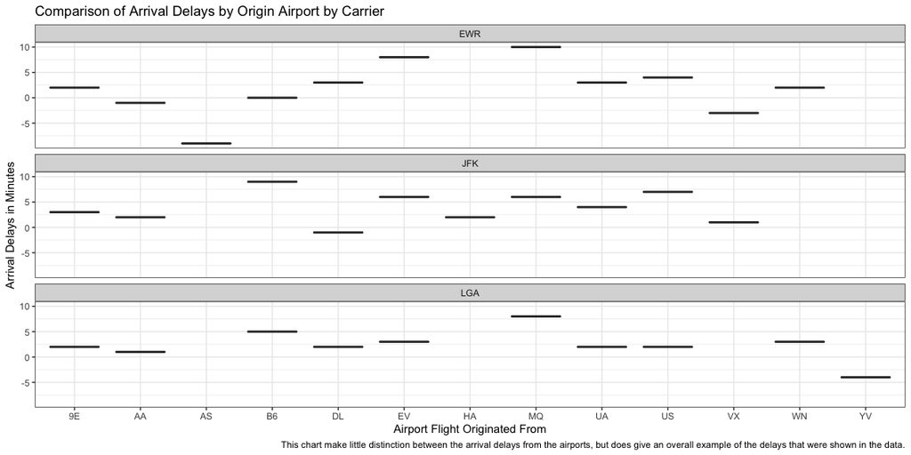

```r
fltdy2a <- nycflights13::flights %>%
  select(origin, carrier, dep_delay, arr_delay, dep_time) %>%
  filter(dep_time <= 1200 & carrier != "FL" & carrier != "F9") %>%
  group_by(origin, carrier) %>%
  summarise(Q3 = quantile(arr_delay, 0.75, na.rm = T))

ggplot(data = fltdy2a, aes(x = carrier, y = Q3)) +
  geom_boxplot() +
  facet_wrap(~origin, ncol = 1) +
  labs(title = "Comparison of Arrival Delays by Origin Airport by Carrier", caption = "This chart make little distinction between the arrival delays from the airports, but does give an overall example of the delays that were shown in the data.",
       x = "Airport Flight Originated From", y = "Arrival Delays in Minutes") +
  theme_bw() +
  theme(legend.position = "none")
```

## Analysis:

##### Worst Airport Arrival Time

###### Recommendation: Avoid LAX

This chart shows the median true arrival time by airport. To find the true arrival time, I subtracted any gains or losses due to departure time. I found the median true arrival time for each airport and used that amount to determine which airports had the worst delay times.

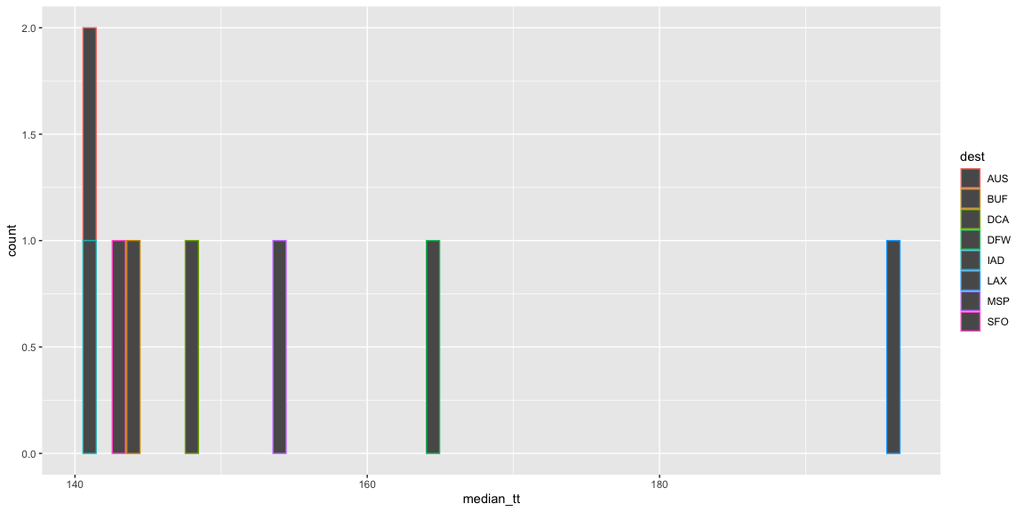

```r
fltdy4 <- (nycflights13::flights) %>%
  group_by(dest) %>%
  filter(dep_delay != "NA" & arr_delay != "NA", tailnum != "N635AA" & dep_delay <= 0) %>%
  mutate(true_time = (arr_delay-dep_delay)) %>%
  filter(true_time > 140) %>%
  summarise(median_tt = median(true_time)) %>%
  select(dest, median_tt)

ggplot(data = fltdy4, aes(x = median_tt)) +
  geom_bar(aes(color = dest))
```

## Conclusion:

LAX has a median arrival delay of 196 minutes. LAX is also one of the largest airports in the US, and there is plenty of data to support this.

I have personally sat on the tarmac for over an hour after I landed at LAX waiting for our turn to dismbark. Doing this report will help me to remember to avoid LAX when I go to California.